# Latihan Pertemuan 6

Pemodelan ARIMA: Pendugaan Parameter, Diagnostik Model, dan Peramalan

Muhammad Shira Pramudita - M0401241094

30 September 2026

# LIBRARY

```r
library(ggplot2)
library(tseries)
library(MASS)
library(forecast)
library(TSA)
library(lmtest)
library(graphics)
```

# INPUT DATA

Data yang dipakai adalah pangsa energi terbarukan harian Jerman tahun 2023 sebanyak 365 amatan, yaitu bagian data yang menjadi jatah pengerjaan dalam kelompok. Sumbernya Energy-Charts, Fraunhofer Institute for Solar Energy Systems, yang menghimpun data asli dari Bundesnetzagentur dengan lisensi CC BY 4.0.

```r
dt <- read.csv("Data-Pangsa-Terbarukan-Jerman-2023.csv")
dt$Tanggal <- as.Date(dt$Tanggal)
head(dt)
```

|  | Tanggal | Hari | Pangsa |
| --- | --- | --- | --- |
| 1 | 2023-01-01 | Min | 74.36 |
| 2 | 2023-01-02 | Sen | 62.77 |
| 3 | 2023-01-03 | Sel | 49.37 |
| 4 | 2023-01-04 | Rab | 75.75 |
| 5 | 2023-01-05 | Kam | 58.67 |
| 6 | 2023-01-06 | Jum | 60.81 |

```r
str(dt)
```

```
## 'data.frame':    365 obs. of  3 variables:
##  $ Tanggal: Date, format: "2023-01-01" "2023-01-02" ...
##  $ Hari   : chr  "Min" "Sen" "Sel" "Rab" ...
##  $ Pangsa : num  74.4 62.8 49.4 75.8 58.7 ...
```

## Bagi Menjadi Data Train dan Test

Pembagian memakai perbandingan 80 persen berbanding 20 persen, sehingga data latih berisi 292 amatan dan data uji 73 amatan.

```r
n     <- nrow(dt)
n_tr  <- floor(0.8 * n)
dt.train <- dt[1:n_tr, ]
dt.test  <- dt[(n_tr + 1):n, ]

c(total = n, latih = nrow(dt.train), uji = nrow(dt.test))
```

```
## total latih   uji
##   365   292    73
```

```r
train.ts <- ts(dt.train$Pangsa)
test.ts  <- ts(dt.test$Pangsa)
c(rataan_latih = mean(train.ts), ragam_latih = var(train.ts), rataan_uji = mean(test.ts))
```

```
## rataan_latih  ragam_latih   rataan_uji
##     58.34267    191.52763     59.45589
```

# EKSPLORASI

## Plot Time Series

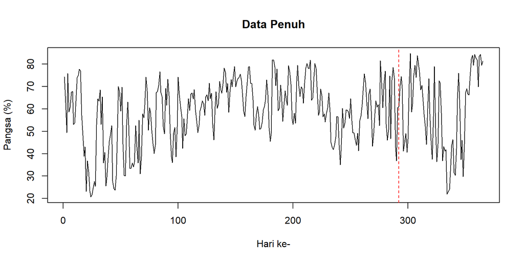

```r
ts.plot(ts(dt$Pangsa), col = "black", lwd = 1,
        xlab = "Hari ke-", ylab = "Pangsa (%)", main = "Data Penuh")
abline(v = n_tr, col = "red", lty = 2)
```

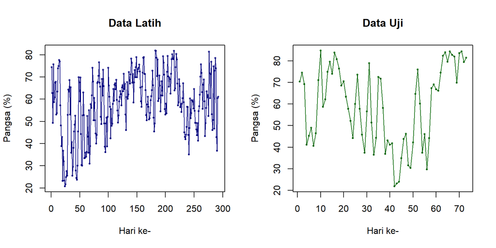

```r
par(mfrow = c(1, 2))
plot(train.ts, col = "navyblue", type = "o", cex = 0.4,
     xlab = "Hari ke-", ylab = "Pangsa (%)", main = "Data Latih")
plot(test.ts, col = "darkgreen", type = "o", cex = 0.4,
     xlab = "Hari ke-", ylab = "Pangsa (%)", main = "Data Uji")
```

Data berfluktuasi lebar antara sekitar 20 persen sampai 85 persen. Tidak terlihat kecenderungan naik atau turun yang tegas sepanjang tahun, tetapi ayunannya cukup besar dari hari ke hari.

# CEK KESTASIONERAN

## Plot ACF

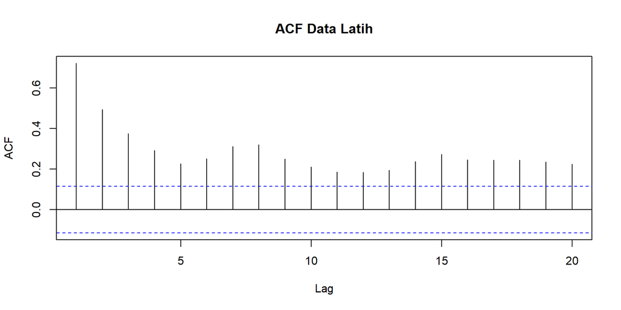

```r
acf(train.ts, main = "ACF Data Latih", lag.max = 20)
```

## Uji ADF

```r
tseries::adf.test(train.ts)
```

```
##
##  Augmented Dickey-Fuller Test
##
## data:  train.ts
## Dickey-Fuller = -3.9377, Lag order = 6, p-value = 0.01253
## alternative hypothesis: stationary
```

Nilai p sebesar 0,0125 berada di bawah 0,05 sehingga secara formal data sudah stasioner dalam rataan. Namun penurunan ACF yang lambat menunjukkan masih ada ketergantungan antarwaktu yang kuat, sehingga pembedaan tetap dicoba dan hasilnya nanti dibandingkan melalui AIC.

## Plot Box-Cox

```r
index <- seq_along(train.ts)
bc <- boxcox(train.ts ~ index, lambda = seq(-3, 4, by = 0.01))
```

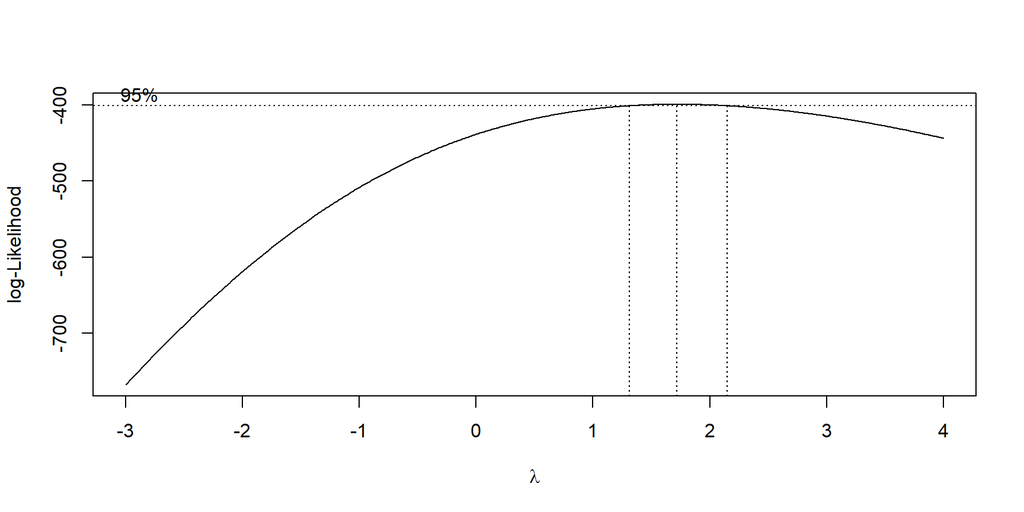

```r
lambda_opt <- bc$x[which.max(bc$y)]
ci_lambda  <- bc$x[bc$y > max(bc$y) - 0.5 * qchisq(0.95, df = 1)]
c(Lambda = round(lambda_opt, 3),
  Batas_Bawah = round(min(ci_lambda), 3),
  Batas_Atas  = round(max(ci_lambda), 3))
```

```
##      Lambda Batas_Bawah  Batas_Atas
##        1.72        1.32        2.15
```

Lambda optimum 1,72 dengan selang 1,32 sampai 2,15. Selang ini tidak memuat nilai satu, sehingga ragamnya belum sepenuhnya stabil. Catatan ini dibawa ke bagian akhir sebagai keterbatasan.

# PENANGANAN KETIDAKSTASIONERAN

## Differencing

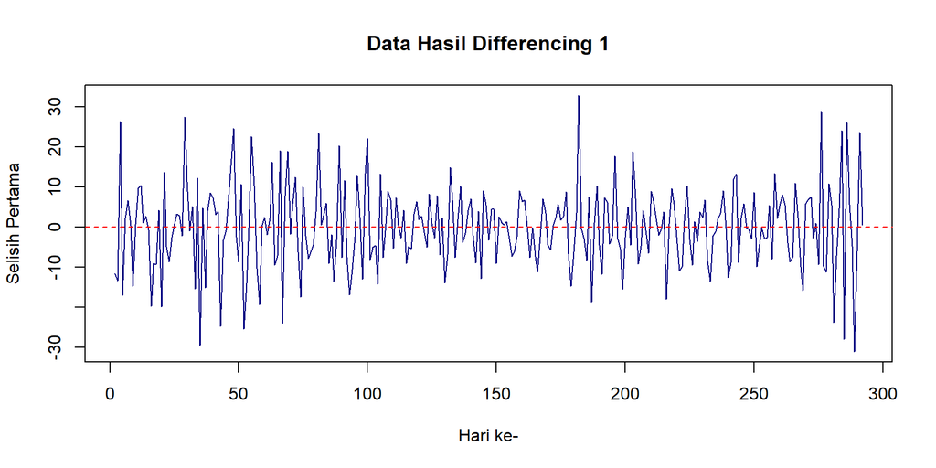

```r
train.diff <- diff(train.ts, differences = 1)
plot.ts(train.diff, lty = 1, xlab = "Hari ke-", ylab = "Selisih Pertama",
        main = "Data Hasil Differencing 1", col = "navyblue")
abline(h = 0, col = "red", lty = 2)
```

## ACF Setelah Differencing

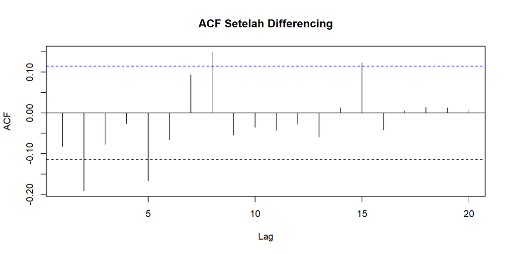

```r
acf(train.diff, main = "ACF Setelah Differencing", lag.max = 20)
```

## Uji ADF Setelah Differencing

```r
tseries::adf.test(train.diff)
```

```
##
##  Augmented Dickey-Fuller Test
##
## data:  train.diff
## Dickey-Fuller = -9.9379, Lag order = 6, p-value = 0.01
## alternative hypothesis: stationary
```

Nilai p turun menjadi 0,01 dan plot ACF langsung terpotong. Data hasil pembedaan sudah stasioner.

# IDENTIFIKASI MODEL

## Plot ACF

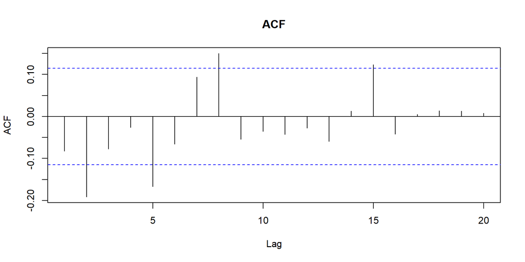

```r
acf(train.diff, main = "ACF", lag.max = 20)
```

## Plot PACF

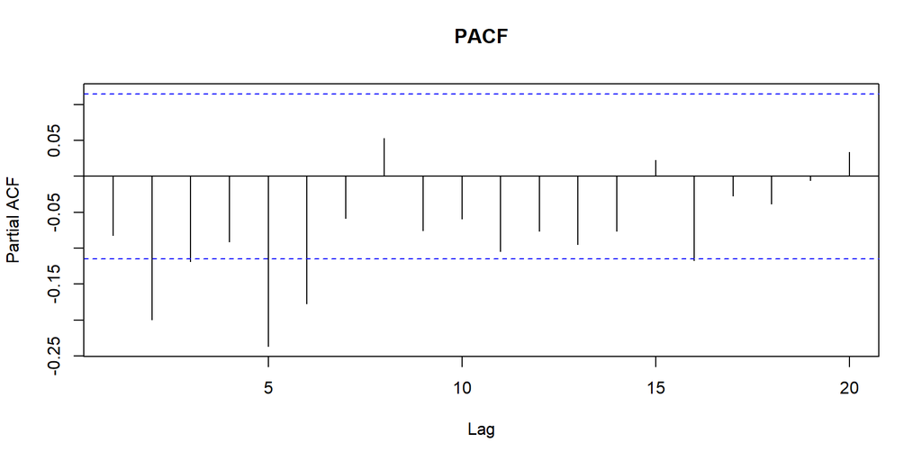

```r
pacf(train.diff, main = "PACF", lag.max = 20)
```

## Plot EACF

```r
eacf(train.diff)
```

```
## AR/MA
##   0 1 2 3 4 5 6 7 8 9 10 11 12 13
## 0 o x o o x o o x o o o  o  o  o
## 1 x x o o x o o x o o o  o  o  o
## 2 x o o o x o o x o o o  o  o  o
## 3 x o x o x o o o o o o  o  o  o
## 4 x x x o x o o o o o o  o  o  o
## 5 x x o x x o x o o o o  o  o  o
## 6 x x o x o o o o o o x  o  o  o
## 7 x o x x o x x o o o o  o  o  o
```

# PENDUGAAN PARAMETER MODEL TENTATIF

Pendugaan dilakukan pada data hasil pembedaan, sehingga ordo pembedaan ditulis nol di dalam fungsi `Arima()` tetapi maknanya tetap ARIMA dengan d sama dengan satu.

## ARIMA(0,1,1)

```r
model1 <- Arima(train.diff, order = c(0, 0, 1), method = "ML")
summary(model1)
```

```
## Series: train.diff
## ARIMA(0,0,1) with non-zero mean
##
## Coefficients:
##           ma1     mean
##       -0.1462  -0.0410
## s.e.   0.0804   0.5106
##
## sigma^2 = 104.7:  log likelihood = -1088.6
## AIC=2183.21   AICc=2183.29   BIC=2194.23
##
## Training set error measures:
##                        ME     RMSE      MAE      MPE     MAPE     MASE
## Training set -0.007023408 10.19537 7.863377 86.91165 146.6293 0.685239
##                    ACF1
## Training set 0.03265934
```

```r
lmtest::coeftest(model1)
```

```
##
## z test of coefficients:
##
##            Estimate Std. Error z value Pr(>|z|)
## ma1       -0.146209   0.080406 -1.8184   0.0690 .
## intercept -0.041039   0.510584 -0.0804   0.9359
## ---
## Signif. codes:  0 '***' 0.001 '**' 0.01 '*' 0.05 '.' 0.1 ' ' 1
```

## ARIMA(1,1,0)

```r
model2 <- Arima(train.diff, order = c(1, 0, 0), method = "ML")
summary(model2)
```

```
## Series: train.diff
## ARIMA(1,0,0) with non-zero mean
##
## Coefficients:
##           ar1     mean
##       -0.0824  -0.0427
## s.e.   0.0585   0.5537
##
## sigma^2 = 105.2:  log likelihood = -1089.33
## AIC=2184.66   AICc=2184.74   BIC=2195.68
##
## Training set error measures:
##                        ME     RMSE      MAE      MPE    MAPE      MASE
## Training set -0.003149172 10.22103 7.846805 92.37259 121.341 0.6837948
##                     ACF1
## Training set -0.01634939
```

```r
lmtest::coeftest(model2)
```

```
##
## z test of coefficients:
##
##            Estimate Std. Error z value Pr(>|z|)
## ar1       -0.082430   0.058453 -1.4102   0.1585
## intercept -0.042704   0.553687 -0.0771   0.9385
```

## ARIMA(1,1,1)

```r
model3 <- Arima(train.diff, order = c(1, 0, 1), method = "ML")
summary(model3)
```

```
## Series: train.diff
## ARIMA(1,0,1) with non-zero mean
##
## Coefficients:
##          ar1      ma1    mean
##       0.6582  -0.9648  0.0233
## s.e.  0.0587   0.0271  0.0657
##
## sigma^2 = 91.26:  log likelihood = -1068.77
## AIC=2145.54   AICc=2145.68   BIC=2160.23
##
## Training set error measures:
##                      ME     RMSE      MAE      MPE    MAPE      MASE       ACF1
## Training set -0.2842237 9.503886 7.431768 83.34123 202.479 0.6476272 0.07000318
```

```r
lmtest::coeftest(model3)
```

```
##
## z test of coefficients:
##
##            Estimate Std. Error  z value Pr(>|z|)
## ar1        0.658177   0.058725  11.2078   <2e-16 ***
## ma1       -0.964844   0.027090 -35.6165   <2e-16 ***
## intercept  0.023262   0.065669   0.3542   0.7232
## ---
## Signif. codes:  0 '***' 0.001 '**' 0.01 '*' 0.05 '.' 0.1 ' ' 1
```

## ARIMA(1,1,2)

```r
model4 <- Arima(train.diff, order = c(1, 0, 2), method = "ML")
summary(model4)
```

```
## Series: train.diff
## ARIMA(1,0,2) with non-zero mean
##
## Coefficients:
##          ar1      ma1      ma2    mean
##       0.5177  -0.7521  -0.1820  0.0126
## s.e.  0.1039   0.1119   0.0877  0.0822
##
## sigma^2 = 90.41:  log likelihood = -1066.82
## AIC=2143.64   AICc=2143.85   BIC=2162.01
##
## Training set error measures:
##                      ME     RMSE      MAE      MPE     MAPE      MASE
## Training set -0.2174988 9.442613 7.336888 82.85498 187.6089 0.6393591
##                     ACF1
## Training set 0.001292984
```

```r
lmtest::coeftest(model4)
```

```
##
## z test of coefficients:
##
##            Estimate Std. Error z value  Pr(>|z|)
## ar1        0.517668   0.103949  4.9800 6.358e-07 ***
## ma1       -0.752126   0.111938 -6.7191 1.828e-11 ***
## ma2       -0.182035   0.087703 -2.0756   0.03793 *
## intercept  0.012603   0.082194  0.1533   0.87813
## ---
## Signif. codes:  0 '***' 0.001 '**' 0.01 '*' 0.05 '.' 0.1 ' ' 1
```

## ARIMA(2,1,1)

```r
model5 <- Arima(train.diff, order = c(2, 0, 1), method = "ML")
summary(model5)
```

```
## Series: train.diff
## ARIMA(2,0,1) with non-zero mean
##
## Coefficients:
##          ar1      ar2      ma1    mean
##       0.7022  -0.1229  -0.9391  0.0101
## s.e.  0.0672   0.0632   0.0390  0.0866
##
## sigma^2 = 90.47:  log likelihood = -1066.9
## AIC=2143.8   AICc=2144.01   BIC=2162.17
##
## Training set error measures:
##                      ME     RMSE      MAE      MPE     MAPE      MASE
## Training set -0.2018282 9.445714 7.342761 79.74035 182.9846 0.6398708
##                     ACF1
## Training set 0.003468278
```

```r
lmtest::coeftest(model5)
```

```
##
## z test of coefficients:
##
##            Estimate Std. Error  z value Pr(>|z|)
## ar1        0.702172   0.067208  10.4477   <2e-16 ***
## ar2       -0.122902   0.063168  -1.9456   0.0517 .
## ma1       -0.939107   0.038982 -24.0907   <2e-16 ***
## intercept  0.010056   0.086599   0.1161   0.9076
## ---
## Signif. codes:  0 '***' 0.001 '**' 0.01 '*' 0.05 '.' 0.1 ' ' 1
```

## ARIMA(2,1,2)

```r
model6 <- Arima(train.diff, order = c(2, 0, 2), method = "ML")
summary(model6)
```

```
## Series: train.diff
## ARIMA(2,0,2) with non-zero mean
##
## Coefficients:
##          ar1     ar2      ma1      ma2    mean
##       0.5017  0.0115  -0.7364  -0.1976  0.0129
## s.e.  0.4169  0.2905   0.4117   0.4016  0.0821
##
## sigma^2 = 90.72:  log likelihood = -1066.82
## AIC=2145.64   AICc=2145.94   BIC=2167.68
##
## Training set error measures:
##                      ME     RMSE      MAE     MPE     MAPE      MASE       ACF1
## Training set -0.2192544 9.442531 7.336354 83.1566 188.0578 0.6393125 0.00153164
```

```r
lmtest::coeftest(model6)
```

```
##
## z test of coefficients:
##
##            Estimate Std. Error z value Pr(>|z|)
## ar1        0.501697   0.416913  1.2034  0.22884
## ar2        0.011458   0.290503  0.0394  0.96854
## ma1       -0.736424   0.411677 -1.7888  0.07364 .
## ma2       -0.197558   0.401637 -0.4919  0.62280
## intercept  0.012892   0.082059  0.1571  0.87516
## ---
## Signif. codes:  0 '***' 0.001 '**' 0.01 '*' 0.05 '.' 0.1 ' ' 1
```

# RINGKASAN AIC

```r
model_tentatif <- data.frame(
  Model = c("ARIMA(0,1,1)", "ARIMA(1,1,0)", "ARIMA(1,1,1)",
            "ARIMA(1,1,2)", "ARIMA(2,1,1)", "ARIMA(2,1,2)"),
  AIC = c(AIC(model1), AIC(model2), AIC(model3), AIC(model4), AIC(model5), AIC(model6)),
  BIC = c(BIC(model1), BIC(model2), BIC(model3), BIC(model4), BIC(model5), BIC(model6))
)
model_tentatif$AIC <- round(model_tentatif$AIC, 2)
model_tentatif$BIC <- round(model_tentatif$BIC, 2)
model_tentatif[order(model_tentatif$AIC), ]
```

|  | Model | AIC | BIC |
| --- | --- | --- | --- |
| 4 | ARIMA(1,1,2) | 2143.64 | 2162.01 |
| 5 | ARIMA(2,1,1) | 2143.80 | 2162.17 |
| 3 | ARIMA(1,1,1) | 2145.54 | 2160.23 |
| 6 | ARIMA(2,1,2) | 2145.64 | 2167.68 |
| 1 | ARIMA(0,1,1) | 2183.21 | 2194.23 |
| 2 | ARIMA(1,1,0) | 2184.66 | 2195.68 |

AIC terkecil dimiliki ARIMA(1,1,2) sebesar 2143,64, disusul ARIMA(2,1,1) sebesar 2143,80. Keduanya berdekatan, tetapi ARIMA(1,1,2) unggul karena seluruh parameter ARMA-nya nyata, sedangkan pada ARIMA(2,1,1) ada parameter yang tidak nyata. Model ARIMA(0,1,1) dan ARIMA(1,1,0) tertinggal jauh dengan AIC di atas 2183.

# ANALISIS SISAAN

Model terpilih sementara adalah ARIMA(1,1,2).

```r
model_terbaik <- model4
sisaan <- residuals(model_terbaik)
```

## Eksplorasi Sisaan

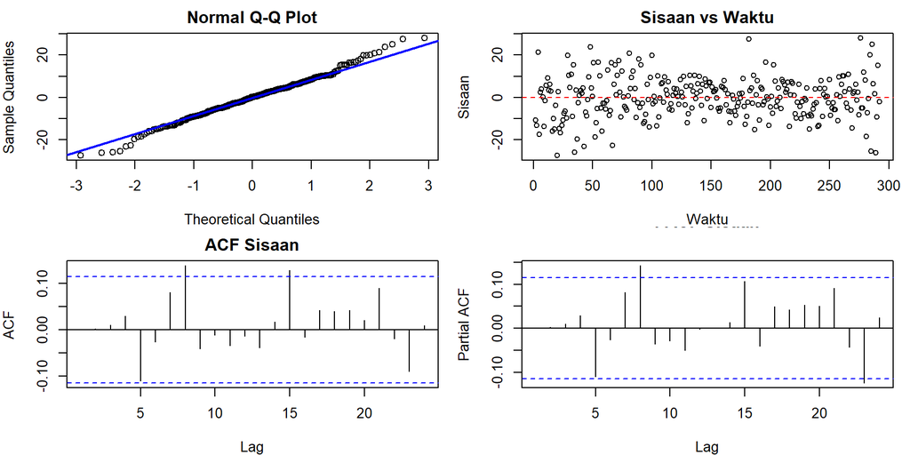

```r
par(mfrow = c(2, 2), mar = c(4, 4, 2, 1))
qqnorm(sisaan, main = "Normal Q-Q Plot"); qqline(sisaan, col = "blue", lwd = 2)
plot(sisaan, type = "p", main = "Sisaan vs Waktu", xlab = "Waktu", ylab = "Sisaan")
abline(h = 0, col = "red", lty = 2)
acf(sisaan, main = "ACF Sisaan")
pacf(sisaan, main = "PACF Sisaan")
```

## Uji Formal

### Normalitas

```r
ks.test(sisaan, "pnorm", mean(sisaan), sd(sisaan))
```

```
##
##  Asymptotic one-sample Kolmogorov-Smirnov test
##
## data:  sisaan
## D = 0.038796, p-value = 0.7735
## alternative hypothesis: two-sided
```

```r
jarque.bera.test(sisaan)
```

```
##
##  Jarque Bera Test
##
## data:  sisaan
## X-squared = 2.7877, df = 2, p-value = 0.2481
```

Nilai p uji Kolmogorov-Smirnov 0,7735 dan Jarque-Bera 0,2481. Keduanya jauh di atas 0,05 sehingga asumsi kenormalan terpenuhi.

### Sisaan Saling Bebas

```r
Box.test(sisaan, type = "Ljung")
```

```
##
##  Box-Ljung test
##
## data:  sisaan
## X-squared = 0.00049153, df = 1, p-value = 0.9823
```

Nilai p 0,9823 sehingga tidak ada bukti autokorelasi pada sisaan.

### Ragam Sisaan Homogen

```r
Box.test(sisaan^2, type = "Ljung")
```

```
##
##  Box-Ljung test
##
## data:  sisaan^2
## X-squared = 1.3935, df = 1, p-value = 0.2378
```

Nilai p 0,2378 sehingga ragam sisaan dapat dianggap homogen.

### Nilai Tengah Sisaan Sama dengan Nol

```r
t.test(sisaan, mu = 0, conf.level = 0.95)
```

```
##
##  One Sample t-test
##
## data:  sisaan
## t = -0.39235, df = 290, p-value = 0.6951
## alternative hypothesis: true mean is not equal to 0
## 95 percent confidence interval:
##  -1.3085429  0.8735454
## sample estimates:
##  mean of x
## -0.2174988
```

Nilai p 0,6951 sehingga nilai tengah sisaan tidak berbeda nyata dari nol. Keempat asumsi terpenuhi.

# OVERFITTING

Model overfitting dibentuk dengan menaikkan satu ordo pada komponen AR maupun MA dari model terpilih.

```r
over1 <- Arima(train.diff, order = c(2, 0, 2), method = "ML")
over2 <- Arima(train.diff, order = c(1, 0, 3), method = "ML")
over3 <- Arima(train.diff, order = c(3, 0, 1), method = "ML")

data.frame(
  Model = c("ARIMA(1,1,2) terpilih", "ARIMA(2,1,2)", "ARIMA(1,1,3)", "ARIMA(3,1,1)"),
  AIC = round(c(AIC(model_terbaik), AIC(over1), AIC(over2), AIC(over3)), 2)
)
```

| Model | AIC |
| --- | --- |
| ARIMA(1,1,2) terpilih | 2143.64 |
| ARIMA(2,1,2) | 2145.64 |
| ARIMA(1,1,3) | 2145.64 |
| ARIMA(3,1,1) | 2145.70 |

```r
lmtest::coeftest(over1)
```

```
##
## z test of coefficients:
##
##            Estimate Std. Error z value Pr(>|z|)
## ar1        0.501697   0.416913  1.2034  0.22884
## ar2        0.011458   0.290503  0.0394  0.96854
## ma1       -0.736424   0.411677 -1.7888  0.07364 .
## ma2       -0.197558   0.401637 -0.4919  0.62280
## intercept  0.012892   0.082059  0.1571  0.87516
## ---
## Signif. codes:  0 '***' 0.001 '**' 0.01 '*' 0.05 '.' 0.1 ' ' 1
```

Tidak ada model overfitting yang menghasilkan AIC lebih kecil dari 2143,64, dan pada ARIMA(2,1,2) justru tidak ada parameter yang nyata. Model ARIMA(1,1,2) dipertahankan.

# MODEL TERBAIK: ARIMA(1,1,2)

```r
lmtest::coeftest(model_terbaik)
```

```
##
## z test of coefficients:
##
##            Estimate Std. Error z value  Pr(>|z|)
## ar1        0.517668   0.103949  4.9800 6.358e-07 ***
## ma1       -0.752126   0.111938 -6.7191 1.828e-11 ***
## ma2       -0.182035   0.087703 -2.0756   0.03793 *
## intercept  0.012603   0.082194  0.1533   0.87813
## ---
## Signif. codes:  0 '***' 0.001 '**' 0.01 '*' 0.05 '.' 0.1 ' ' 1
```

Ketiga parameter ARMA nyata pada taraf 5 persen, yaitu koefisien AR sebesar 0,5177, MA pertama sebesar -0,7521, dan MA kedua sebesar -0,1820. Konstanta tidak nyata, yang wajar karena data sudah dibedakan.

# PERAMALAN

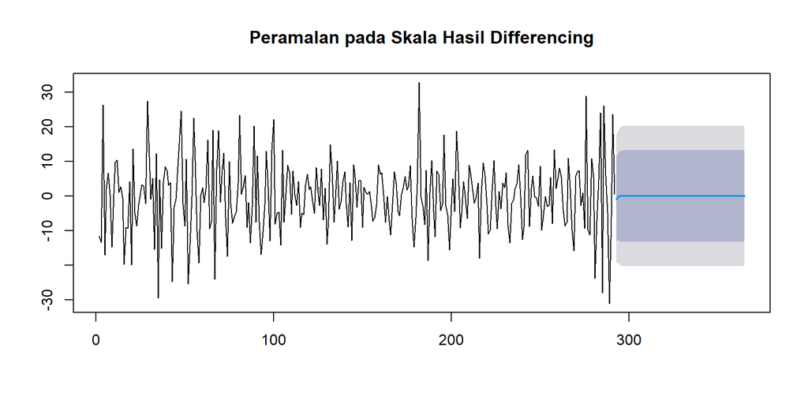

```r
ramalan <- forecast::forecast(model_terbaik, h = nrow(dt.test))
plot(ramalan, main = "Peramalan pada Skala Hasil Differencing")
```

Ramalan di atas masih berada pada skala selisih, sehingga perlu dikembalikan ke skala asli melalui proses kebalikan pembedaan.

```r
pt_akhir <- tail(dt.train$Pangsa, 1)
pt_akhir
```

```
## [1] 61.1
```

```r
hasil <- diffinv(as.numeric(ramalan$mean), differences = 1, xi = pt_akhir)[-1]
perbandingan <- data.frame(
  Tanggal  = dt.test$Tanggal,
  Aktual   = dt.test$Pangsa,
  Ramalan  = round(hasil, 2)
)
head(perbandingan, 10)
```

|  | Tanggal | Aktual | Ramalan |
| --- | --- | --- | --- |
| 1 | 2023-10-20 | 70.36 | 60.23 |
| 2 | 2023-10-21 | 74.49 | 60.16 |
| 3 | 2023-10-22 | 69.20 | 60.13 |
| 4 | 2023-10-23 | 41.14 | 60.12 |
| 5 | 2023-10-24 | 45.24 | 60.12 |
| 6 | 2023-10-25 | 49.02 | 60.13 |
| 7 | 2023-10-26 | 40.63 | 60.14 |
| 8 | 2023-10-27 | 46.42 | 60.15 |
| 9 | 2023-10-28 | 71.01 | 60.16 |
| 10 | 2023-10-29 | 84.76 | 60.17 |

## Akurasi

```r
akurasi <- accuracy(hasil, dt.test$Pangsa)
round(akurasi, 4)
```

```
##               ME    RMSE    MAE      MPE    MAPE
## Test set -1.0589 18.0465 15.788 -14.7424 33.7089
```

## Perbandingan dengan Ramalan Naif

Ramalan naif memakai nilai terakhir data latih untuk seluruh periode uji. Pembanding ini dipakai untuk memastikan model benar-benar memberi tambahan manfaat.

```r
naif <- rep(pt_akhir, nrow(dt.test))
data.frame(
  Metode = c("ARIMA(1,1,2)", "Ramalan naif"),
  MAPE = round(c(mean(abs((dt.test$Pangsa - hasil) / dt.test$Pangsa)) * 100,
                 mean(abs((dt.test$Pangsa - naif) / dt.test$Pangsa)) * 100), 3),
  RMSE = round(c(sqrt(mean((dt.test$Pangsa - hasil)^2)),
                 sqrt(mean((dt.test$Pangsa - naif)^2))), 3)
)
```

| Metode | MAPE | RMSE |
| --- | --- | --- |
| ARIMA(1,1,2) | 33.709 | 18.046 |
| Ramalan naif | 34.065 | 18.118 |

## Plot Ramalan terhadap Data Aktual

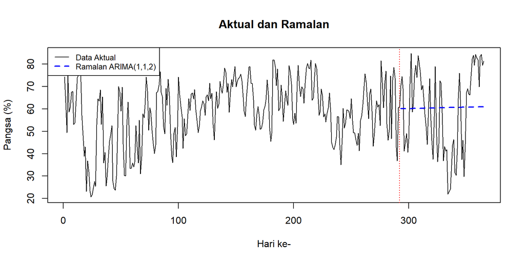

```r
ts.plot(ts(dt$Pangsa), col = "black", lty = 1,
        xlab = "Hari ke-", ylab = "Pangsa (%)", main = "Aktual dan Ramalan")
lines((n_tr + 1):(n_tr + length(hasil)), hasil, col = "blue", lty = 2, lwd = 2)
abline(v = n_tr, col = "red", lty = 3)
legend("topleft", legend = c("Data Aktual", "Ramalan ARIMA(1,1,2)"),
       col = c("black", "blue"), lty = c(1, 2), lwd = c(1, 2), cex = 0.8)
```

Garis ramalan mendatar di sekitar 60 persen, sedangkan data aktual tetap berayun lebar antara 20 sampai 85 persen. Inilah sifat ramalan ARIMA tanpa komponen musiman pada horizon panjang, yaitu cepat menuju nilai tetap.

# KESIMPULAN